# Analysis for PC deletion

Richard Barfield

Biostatistics, Epidemiology and Research Design (BERD) Core

Center for Human Systems Immunology (CHSI)

2025-01-10

# 1 Introduction

Here we are analyzing two different sets of data.

- The first is the Immunocompetent dams comparing PC deleted to PC intact and the immune system response to the infection.
  - Analyzing two different ways
    - First via the AUC over the first 11 weeks
    - 2nd is via a linear mixed effects model.
- 2nd analysis is the dissemination data

# 2 Analysis of PC deleted data

## 2.1 First visualize the data

We first visualize the data over the time period we are interested in.

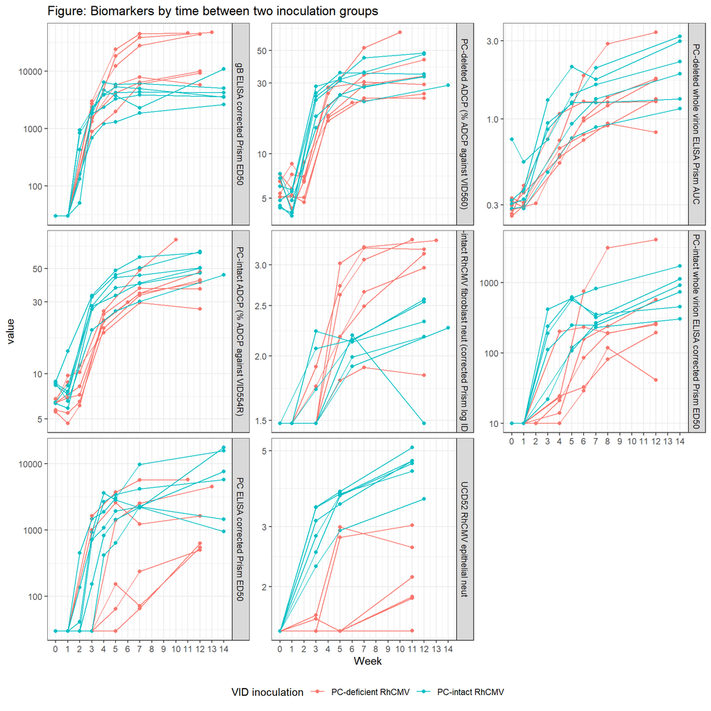

## 2.2 Calculate the AUC

We next calculate the AUC going from week 0 to week 11.

We are filling in those observations that do not have Week 0/11 values.

For the week 0 observations, we will project backwards from the first 2 time points to estimate what the week 0 value would be. This was done on the log10 scale.

Table: Instances of no week 0 value

| Animal ID | Variable | VID inoculation |
| --- | --- | --- |
| PC-intact_2 | PC-intact whole virion ELISA corrected Prism ED50 | PC-intact RhCMV |
| PC-intact_2 | PC-deleted whole virion ELISA Prism AUC | PC-intact RhCMV |
| PC-intact_5 | PC-intact whole virion ELISA corrected Prism ED50 | PC-intact RhCMV |
| PC-intact_5 | PC-deleted whole virion ELISA Prism AUC | PC-intact RhCMV |

Next, are there any instances where there is no week 11 or, no observations post week 11. For these we will just carry forward the week 10 value.

Table: Instances of no week 11+ value

| Animal ID | Variable | VID inoculation | Last Week |
| --- | --- | --- | --- |
| PC-deficient_2 | PC-deleted ADCP (% ADCP against VID560) | PC-deficient RhCMV | 10 |
| PC-deficient_2 | PC-intact ADCP (% ADCP against VID554R) | PC-deficient RhCMV | 10 |

Finally, there are instances of no week 11 but there are observations pre week 11 and after week 11. Here we simply linearly extrapolated between the two values before and after week 11. This was done on the log10 scale.

### 2.2.1 No week 0 values

Will extrapolate backwards to week 0.

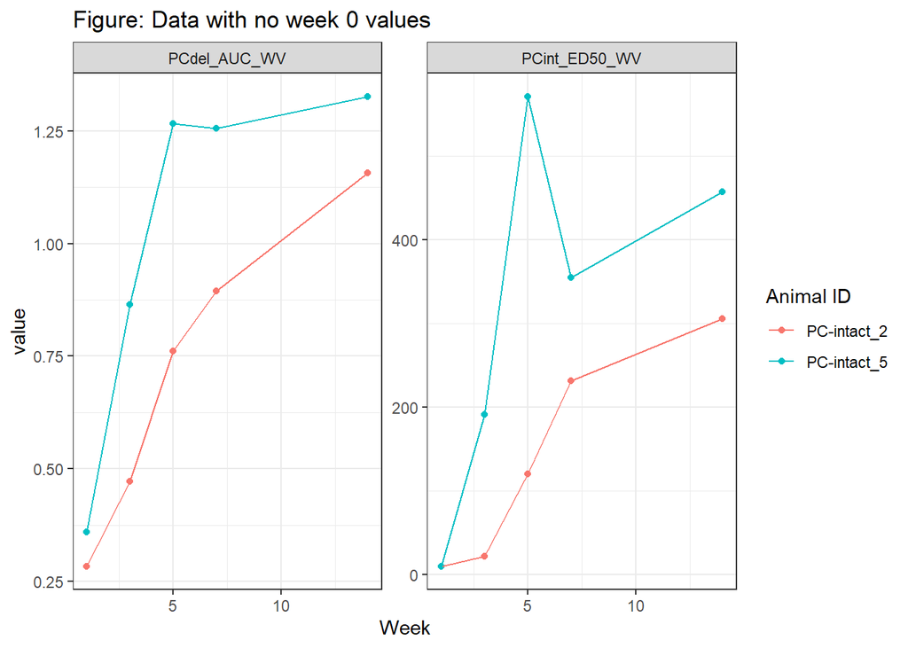

Let’s now zoom in after we’ve done the linear approximation.

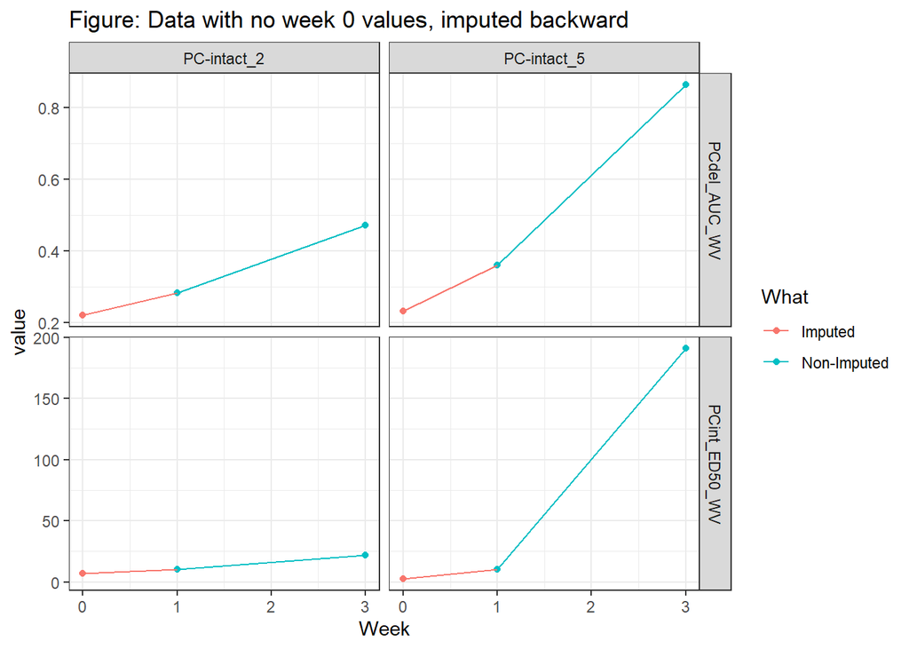

### 2.2.2 No week 11

If there is no week 11 data but there is say a week 10 and 13 observation, we will linearly extrapolate to the week 11 values.

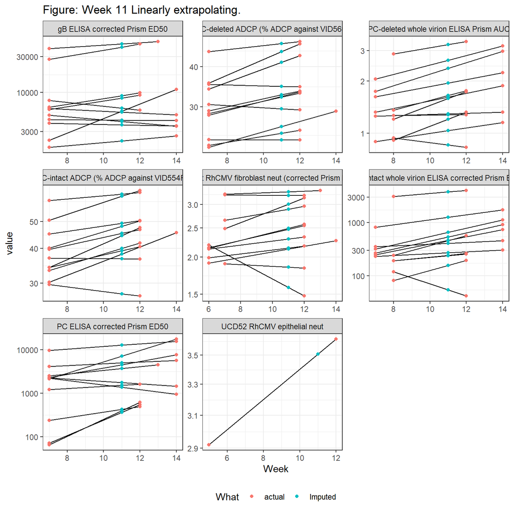

## 2.3 Analyze the AUC/Max data

We will next analyze the AUC/Max data. This was done using a Wilcoxon Rank Sum Test via the coin package which calculates the exact p-value. The exact p-value is based on all the possible permutations given the data and the group size.

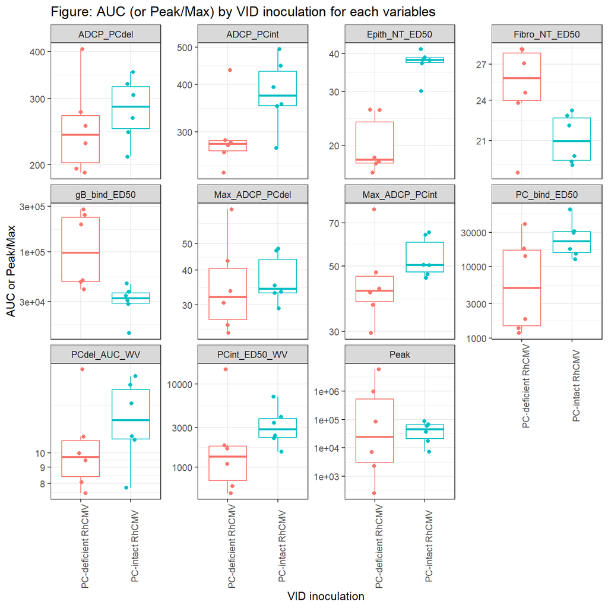

Table: Results from AUC Analysis

| Variable | Pvalue | FDR Pvalue |
| --- | --- | --- |
| UCD52 RhCMV epithelial neut | 0.00216 | 0.0238 |
| gB ELISA corrected Prism ED50 | 0.00433 | 0.0238 |
| PC-intact RhCMV fibroblast neut (corrected Prism log ID50) | 0.0649 | 0.238 |
| PC-intact ADCP (% ADCP against VID554R) | 0.0931 | 0.242 |
| Maximum % ADCP against PC-intact RhCMV (VID554R) | 0.132 | 0.242 |
| PC-intact whole virion ELISA corrected Prism ED50 | 0.132 | 0.242 |
| PC ELISA corrected Prism ED50 | 0.18 | 0.282 |
| PC-deleted whole virion ELISA Prism AUC | 0.31 | 0.426 |
| PC-deleted ADCP (% ADCP against VID560) | 0.394 | 0.481 |
| Maximum % ADCP against PC-deleted RhCMV (VID560) | 0.589 | 0.648 |
| Peak viremia | 0.937 | 0.937 |

**Bold** indicates P-value <0.05 and FDR p-value <0.2  
Pvalues from Wilcoxon Rank Sum Test  
FDR Pvalue from Benjamini Hochberg

We see a few variables that come back as significant.

## 2.4 Linear mixed effects model

We next performed a longitudinal model analyzing the whole time course (not restricting to the first 11 weeks). We are testing for any difference across time with regards to the virus inoculated with.

We ran this two different ways. In the data without any lower limit of detection issues we used the lme4 package, fitting a linear mixed effects model with a random intercept for animal ID. We allowed for a fixed effect for time and Virus. Upon examining the residuals of the data (which can be seen in the appendix), we in addition added an early period effect (prior to week 3). This was done for all variables. Censored linear mixed effects models were fit using the lmec package in R. Multiple testing correction was done as above via FDR.

The final model was then:

$$Y=\alpha_0+\alpha_1\text{(Mutant
Virus)}+\alpha_2\text{Week}+\alpha_3\text{(Before Week 3)}+\text{(Random
intercept for Animal)}+\text{Noise}$$

### 2.4.1 The variables without any censored data

First we will run on the data that has no data at lower limit.

### 2.4.2 Variables that are at a lower bound.

For these we used a linear mixed effects model that allows for censoring.

### 2.4.3 The Results

Table: Results from linear mixed effects model

| Variable | WT vs PC deleted | SE | Pvalue | FDR.pvalue |
| --- | --- | --- | --- | --- |
| UCD52 RhCMV epithelial neut* | 0.33 | 0.0484 | 8.83e-12 | 7.06e-11 |
| PC ELISA corrected Prism ED50* | 0.728 | 0.298 | 0.0146 | 0.0584 |
| PC-intact RhCMV fibroblast neut (corrected Prism log ID50)* | -0.0842 | 0.0391 | 0.0311 | 0.074 |
| PC-intact whole virion ELISA corrected Prism ED50* | 0.426 | 0.204 | 0.037 | 0.074 |
| PC-intact ADCP (% ADCP against VID554R) | 0.297 | 0.157 | 0.0881 | 0.141 |
| PC-deleted whole virion ELISA Prism AUC | 0.0735 | 0.0614 | 0.259 | 0.345 |
| gB ELISA corrected Prism ED50* | -0.114 | 0.123 | 0.355 | 0.405 |
| PC-deleted ADCP (% ADCP against VID560) | -0.00155 | 0.141 | 0.991 | 0.991 |

* indicate results from linear effects model with censored data (i.e. accounting for data at lower bound)  
**Bold** indicates P-value <0.05 and FDR p-value <0.2  
ADCP and Cell-associated gH IgG binding were logit transformed

#### 2.4.3.1 What was called significant?

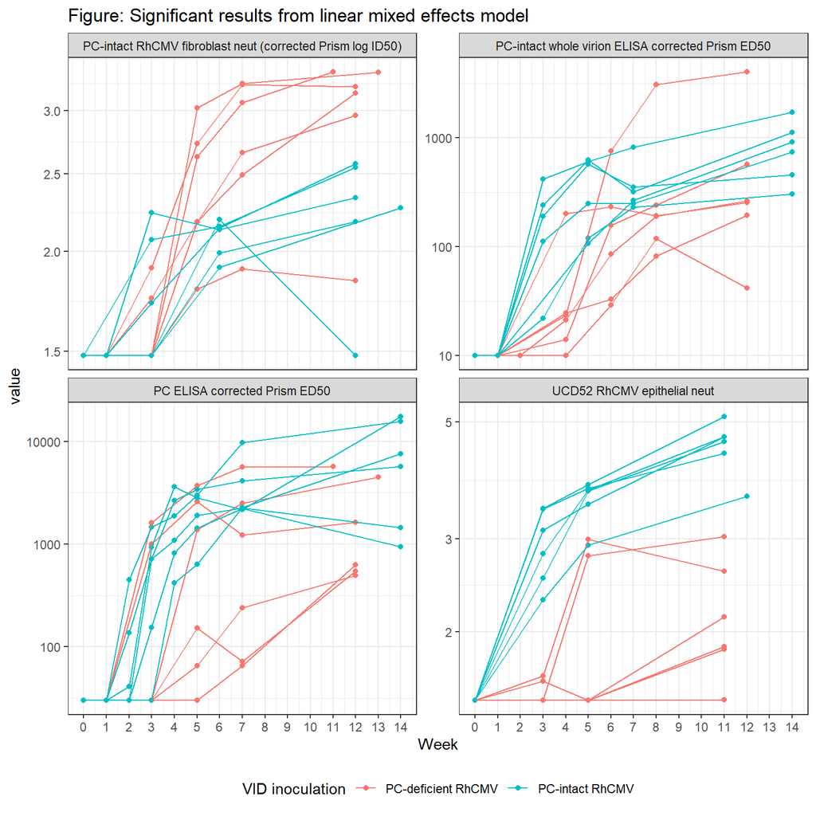

#### 2.4.3.2 What was not called significant

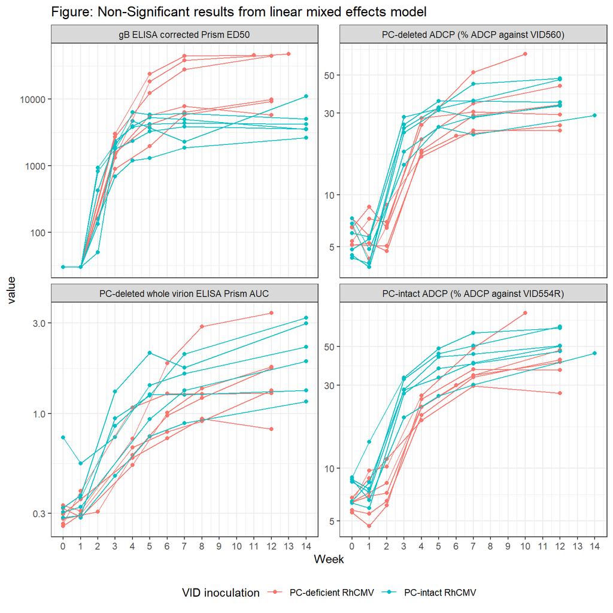

# 3 AUC and Amniotic fluid

Here we look at the AUC calculated above and whether or not it is associated with transmission status via Wilcoxon rank sum test.

Table: Results from AUC Analysis of virus in the Amniotic Fluid

| Variable | Pvalue | FDR Pvalue |
| --- | --- | --- |
| Maximum % ADCP against PC-intact RhCMV (VID554R) | 0.461 | 0.933 |
| PC-intact ADCP (% ADCP against VID554R) | 0.57 | 0.933 |
| PC-intact whole virion ELISA corrected Prism ED50 | 0.57 | 0.933 |
| PC-deleted whole virion ELISA Prism AUC | 0.683 | 0.933 |
| gB ELISA corrected Prism ED50 | 0.683 | 0.933 |
| PC-deleted ADCP (% ADCP against VID560) | 0.808 | 0.933 |
| PC-intact RhCMV fibroblast neut (corrected Prism log ID50) | 0.808 | 0.933 |
| Maximum % ADCP against PC-deleted RhCMV (VID560) | 0.933 | 0.933 |
| PC ELISA corrected Prism ED50 | 0.933 | 0.933 |
| Peak viremia | 0.933 | 0.933 |
| UCD52 RhCMV epithelial neut | 0.933 | 0.933 |

**Bold** indicates P-value <0.05 and FDR p-value <0.2  
Pvalues from Wilcoxon Rank Sum Test  
FDR Pvalue from Benjamini Hochberg

# 4 Dissemination data

Next we look at the dissemination data. For these analyses we removed the draining lymph nodes and the injection sites tissues from the analysis.

- RhCMV.FL.ΔRh157.4-.5-> as PC deleted
- RhCMV.FL.ΔRh158-161-> as UL146

## 4.1 Acounting for data from the Animal.

We next visualize the ratio of the mutant virus count to the wild type virus count (after adding 1 to both to account for 0’s) from the same tissue and the same animal.

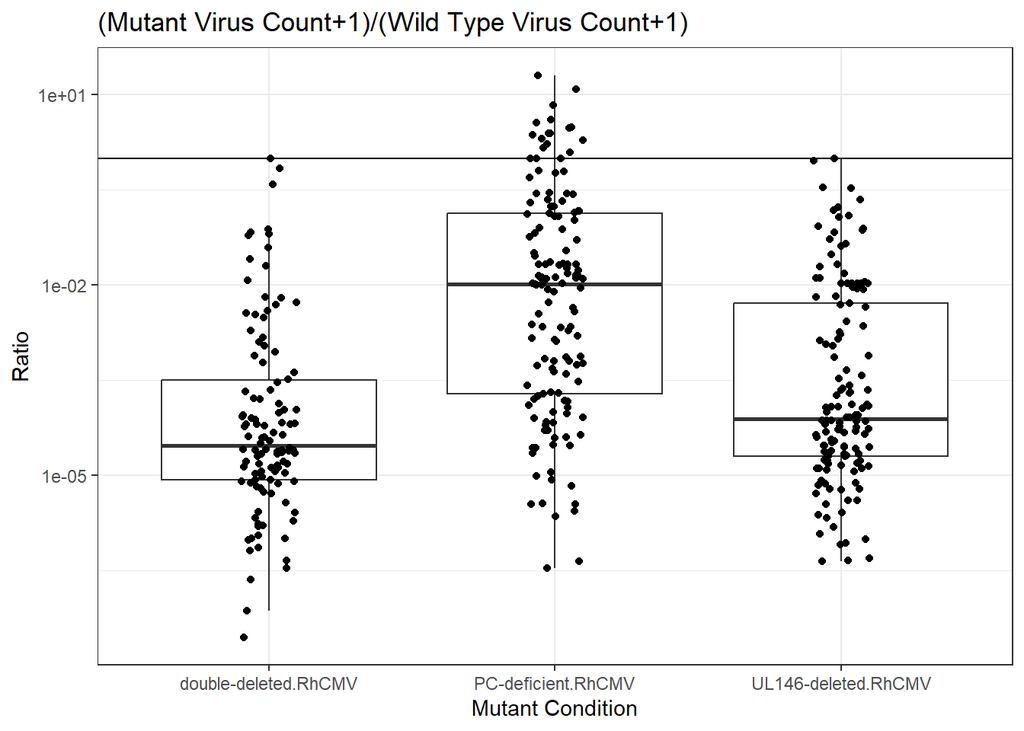

## 4.2 Linear mixed effects model

Restricting to data where have observations in both tissues. No longer dropping the Genitorurinary Tract.

We will model the log10 ratio. The ratio is Mutant Virus count + 1 divided by Wild Type Virus count + 1. We have a random intercept for animal and are testing for whether or not log10 of this ratio is different than 1. We will include as covariate “system” type. We are not adjusting for sex.

Results from linear mixed effects model of log fold change MT vs WT

| Comparison | Estimate | test_statistic | Pvalue | HolmAdjustedPvalue |
| --- | --- | --- | --- | --- |
| double-deleted.RhCMV vs WT | -4.86 | -8.36 | 1.53e-06 | 7.64e-06 |
| PC-deficient.RhCMV vs WT | -2.97 | -5.7 | 4.57e-05 | 0.000183 |
| UL146-deleted.RhCMV vs WT | -4.34 | -8.33 | 6.05e-07 | 3.63e-06 |
| double-deleted.RhCMV vs PC-deficient.RhCMV* | -1.89 | -2.77 | 0.0245 | 0.0736 |
| double-deleted.RhCMV vs UL146-deleted.RhCMV* | -0.518 | -0.759 | 0.47 | 0.47 |
| PC-deficient.RhCMV vs UL146-deleted.RhCMV* | 1.37 | 2.17 | 0.0622 | 0.124 |

* indicates a comparison of MT condition 1 normalized to their WT vs MT condition 2 normalized to their WT